# Lab 4 Evaluation and Multi-Layer Perceptron —— The Quality of Red Wines

47491968 Yuankai Liu  
47511663 Jianing Zhao  
47564911 Yang Peng

# 1. Preparation and Overview

## 1.1 Business understanding

In this lab, The dataset is related the Portuguese "Vinho Verde" red wine. The inputs include objective tests (e.g. PH values) and the output is based on sensory data(median of at least 3 evaluations made by wine experts). Each expert graded the wine quality between 0 (very bad) and 10 (very excellent). We know that many points of view are needed to be considered to describe the quality of red wines. When winery produced batches of red wines and wanted to put them into market, how to set the price of these red wine becomes a problem, despite the fact that they may have a traditional way. Also, When customers want to buy red wines, how to buy good quality of red wines is puzzling.

Therefore, finding a quick and effective way to judge the quality of red wine is meaningful. We will use physicochemical properties to explore a effective method to describe the quality of red wines. We will use F1-score to evaluate the model, and the results can serve as a reference in the field of red wine. Both winery and customers will be interested in this results. Because it can not only help the winery set the price scientifically, but also help customers buy best red wines with limited money.

The classification task is to make a multi-layer perceptron, and we will be using the Redwine Dataset to compare the performance of multi-layer perceptrons programmed in scikit-learn and via our own implementation. we have chosen to tackle a classification problem of redwine quality.

## 1.2 Define and prepare class variables

This dataset has 12 variables and all variables are numerical. There are 1599 rows of instances and there is no missing data in this dataset.

Because we want to classify the different quality of red wines, first we should remove the column of quality and then make matrix representation. After doing those processes, the data can be used for classification. When we get the results of classification, we will compute the F1-score to verify the performance of this model.

```python
from matplotlib import pyplot as plt
import numpy as np
import pandas as pd
from sklearn.cross_validation import train_test_split
from sklearn.metrics import accuracy_score,f1_score
import warnings
warnings.filterwarnings("ignore")
df=pd.read_csv('redwine.csv')
df.shape
y=df['quality']
y=y-3
X= df.drop(['quality'],axis=1)
Xm=np.array(X)
ym=np.array(y)
print(df.info())
```

```
<class 'pandas.core.frame.DataFrame'>
RangeIndex: 1599 entries, 0 to 1598
Data columns (total 12 columns):
fixed acidity           1599 non-null float64
volatile acidity        1599 non-null float64
citric acid             1599 non-null float64
residual sugar          1599 non-null float64
chlorides               1599 non-null float64
free sulfur dioxide     1599 non-null float64
total sulfur dioxide    1599 non-null float64
density                 1599 non-null float64
pH                      1599 non-null float64
sulphates               1599 non-null float64
alcohol                 1599 non-null float64
quality                 1599 non-null int64
dtypes: float64(11), int64(1)
memory usage: 150.0 KB
None
```

In this dataset, there are none missing values.

```python
df.head()
```

|  | fixed acidity | volatile acidity | citric acid | residual sugar | chlorides | free sulfur dioxide | total sulfur dioxide | density | pH | sulphates | alcohol | quality |
| --- | --- | --- | --- | --- | --- | --- | --- | --- | --- | --- | --- | --- |
| 0 | 7.4 | 0.70 | 0.00 | 1.9 | 0.076 | 11.0 | 34.0 | 0.9978 | 3.51 | 0.56 | 9.4 | 5 |
| 1 | 7.8 | 0.88 | 0.00 | 2.6 | 0.098 | 25.0 | 67.0 | 0.9968 | 3.20 | 0.68 | 9.8 | 5 |
| 2 | 7.8 | 0.76 | 0.04 | 2.3 | 0.092 | 15.0 | 54.0 | 0.9970 | 3.26 | 0.65 | 9.8 | 5 |
| 3 | 11.2 | 0.28 | 0.56 | 1.9 | 0.075 | 17.0 | 60.0 | 0.9980 | 3.16 | 0.58 | 9.8 | 6 |
| 4 | 7.4 | 0.70 | 0.00 | 1.9 | 0.076 | 11.0 | 34.0 | 0.9978 | 3.51 | 0.56 | 9.4 | 5 |

### Features

Here is the list of all features that we used:

- fixed acidity
- volatile acidity
- citric acid
- residual sugar
- chlorides
- free sulfur dioxide
- total sulfur dioxide
- density
- pH
- sulphates
- alcohol

We can see that there are only 12 columns, so we don't need to make dimensionality reduction.

All data are numerical, so we can directly normalize these data to bulid our model.

```python
from sklearn import preprocessing
nor_Xm=preprocessing.normalize(Xm)
```

```python
from sklearn.model_selection import StratifiedShuffleSplit
ss=StratifiedShuffleSplit(n_splits=1,test_size=0.2,train_size=0.8,random_state=0)
for train_index, test_index in ss.split(Xm, ym):
   X_train, X_test = nor_Xm[train_index], nor_Xm[test_index]
   y_train, y_test = ym[train_index], ym[test_index]
```

```python
print(np.unique(y_train))
```

```
[0 1 2 3 4 5]
```

# 2 Evaluation

## 2.1 Evaluation Metrics

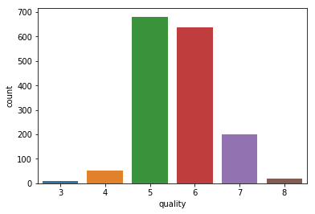

```python
import seaborn as sns

sns.countplot(data=df, x='quality')
plt.show()
```

Genarally, We use accuracy, precision, recall, f1-score, ROC-AUC to evalate the model in binary classification problems. For multi-classification problems, Precision, Recall, and F1 can be calculated separately for each class, and integrated as a model evaluation index.

**Accuracy**: It is the most common and basic evaluation metric.

**Precision**: It is the proportion of "true" samples judged by all systems that is truly true, that is, TP/(TP+FP).

**Recall**: It is the proportion of “true” that is judged to be TP/(TP+FN) in all samples that are truly true.

**F1-score**: The metric designed to comprehensively consider the precision and recall.

**ROC-AUC**: It is the curve of TP vs FP.

But the objective in different situation is totally diferent, which means that the quality of metrics depends on the goals of the classifier. **For instance**, email filtering spam, you want it to be more comprehensive (detect all the junk, but there is a lot of useful information is also judged as junk), or you want it to be as accurate as possible (do not always detect useful email as junk)? Obviously, we think that False Positive's damage is greater than False Negative: the loss of important mail if it is sentenced to junk is far greater than the amount of spam in the inbox. **However**, for the prediction of the earthquake, we hope that recall is very high, that is, we want to predict each earthquake. At this time we can sacrifice percision.

In this lab, our dataset is about the qaulity of red wine and this is an multi-classification question, so some of metrics seems not very meamingful for us and we finally decided to use **F1-score** to evaluate our model. The reasons are as follows.

**First**, the quality distribution of red wine isn't relatively balanced, and we know that if the classes are not balanced,the accuracy evaluation has no reference value. **Second**, We are facing a multi-classification problem, and there are micro or macro average F1-scores that are designed in particular, so we can directly use these. Therefore, in this case, F1-score would tell us that this is actually a pretty good classifier or not.

As for our dataset, we must decide whether a micro or macro average of our scores will be more beneficial.

The macro average is to first calculate the index value for each class and then calculate the arithmetic average of all classes.

The micro average is to establish a global confusion matrix for each instance of the data set without any class, and then calculate the corresponding index.

The difference is that macro average gives each class the same weight, whereas micro average gives each sample the same weight. In the micro average assessment index, the class with more samples dominates the class with fewer samples. However, the quality distribution of red wine isn't relatively balanced and the objective in our dataset is that each class can be accurate enough, because every class is important equally. Therefore, marco average is the appropriate evaluation metric.

In conclusion, we will be using **marco average F1-scroe** to evaluate the performance of multi-layer perceptrons programmed in scikit-learn and via our own custom implementation.

## 2.2 Train/Test Validation Methodology

In addition to deciding on an evaluation metric that is more appropriate for our business use case, we must also determine the best method by which to divide our data into training and testing splits.

Once again, we are haunted by the curse of unbalanced classes. As far as possible to ensure that each classification of data in the test set and training the same proportion, we choose to use the method of sklearn to split the data.

First of all, we split our data into training and testing splits by 80%/20% in 1.2, and the process of splits are stratified. The testing set will be used for the final customized model and sklearn model to compare the performance.

Then, in the cases of extreme class imbalance, we would want to use a stratified 5-fold cross validation to help ensure a proper ratio between the classes are represented within each fold. We use this stratified 5-fold cross validation set in 3.2 to find the proper hyperparameter for our customized model.

# 3 Modeling

## 3.1 Create a custom implementation

Now that we have read in our data, cleaned the dataset, prepared the data, and chosen appropriate evaluation and cross-validation methods, we can begin our custom implementation of a Multi-Layer Perceptron.

Custom implementation includes:

When instantiated, use a selectable phi function for the initial layer: sigmoid or linear or Relu or Silu.

Use a selectable cost function when instantiated: either MSE or cross entropy.

Add support for any number of hidden layers(user customizable,and we chose 1, 2, 7).

```python
import numpy as np
from scipy.special import expit
import sys

# start with a simple base classifier, which can't be fit or predicted
# it only has internal classes to be used by classes that will subclass it
class TwoLayerPerceptronBase(object):
    def __init__(self, n_hidden=30,
                 C=0, epochs=500, eta=0.001, random_state=None):
        np.random.seed(random_state)
        self.n_hidden = n_hidden
        self.l2_C = C
        self.epochs = epochs
        self.eta = eta

    @staticmethod
    def _encode_labels(y):
        """Encode labels into one-hot representation"""
        onehot = pd.get_dummies(y).values.T

        return onehot

    def _initialize_weights(self):
        """Initialize weights with small random numbers."""
        W1_num_elems = (self.n_features_ + 1)*self.n_hidden
        W1 = np.random.uniform(-1.0, 1.0, size=W1_num_elems)
        W1 = W1.reshape(self.n_hidden, self.n_features_ + 1) # reshape to be W

        W2_num_elems = (self.n_hidden + 1)*self.n_output_
        W2 = np.random.uniform(-1.0, 1.0, size=W2_num_elems)
        W2 = W2.reshape(self.n_output_, self.n_hidden + 1)
        return W1, W2


    def _activation(self, z):
        if self.phi == 'sigmoid':
            return expit(z)
        elif self.phi == 'linear':
            return z
        elif self.phi == 'relu':
            return z * (z > 0)
        elif self.phi == 'silu':
            return z * expit(z)

    @staticmethod
    def _add_bias_unit(X, how='column'):
        if how == 'column':
            ones = np.ones((X.shape[0], 1))
            X_new = np.hstack((ones, X))
        elif how == 'row':
            ones = np.ones((1, X.shape[1]))
            X_new = np.vstack((ones, X))
        return X_new

    @staticmethod
    def _L2_reg(lambda_, W1, W2):
        """Compute L2-regularization cost"""
        # only compute for non-bias terms
        return (lambda_/2.0) * np.sqrt(np.mean(W1[:, 1:] ** 2) + np.mean(W2[:, 1:] ** 2))

    def _cost(self,A3,Y_enc,W1,W2):
        '''Get the objective function value'''
        cost = np.mean((Y_enc-A3)**2)
        L2_term = self._L2_reg(self.l2_C, W1, W2)
        return cost + L2_term
```

```python
class CustizedPerceptron(TwoLayerPerceptronBase):


    def __init__(self, nl_hidden=1, phi='relu',cost='cross-entropy',**kwds):
        self.nl_hidden = nl_hidden
        self.n_layers = self.nl_hidden + 1

        self.phi = phi
        self.cost = cost

        super().__init__(**kwds)

    def _phi_function(self, A):
        if self.phi == 'sigmoid':
            return A * (1 - A)
        elif self.phi == 'linear':
            return np.ones(A.shape)
        elif self.phi == 'relu':
            return np.ones(A.shape) * (A > 0)
        elif self.phi == 'silu':
            return expit(A) + A * expit(A) * (1 - expit(A))



    def _cost_grad(self, A, Y):
        if self.cost == 'mse':
            return -2 * (Y - A) * (1 - A)
        elif self.cost == 'cross-entropy':
            return (A - Y)


    def _get_gradient(self, results, outputs, Y):
        sensitivity = self.network_.copy()
        sensitivity[-1] = self._cost_grad(results[-1], Y)
        self.grads_[-1] = sensitivity[-1] @ results[-2].T
        self.grads_[-1] += self.network_[-1] * self.l2_C
        for i in range(-2, -self.n_layers, -1):
            if i == -2:
                sensitivity[i] = (self._phi_function(results[i]) *
                                  (self.network_[i+1].T @ sensitivity[i+1]))
            else:
                sensitivity[i] = (self._phi_function(results[i]) *
                                  (self.network_[i+1].T @ sensitivity[i+1][1:,:]))

            self.grads_[i] = sensitivity[i][1:,:] @ results[i-1].T
            self.grads_[i][:,1:] += self.network_[i][:,1:] * self.l2_C

    def _feedforward(self, X):
        result = []
        outputs = []

        A = self._add_bias_unit(X, how='column').T
        result.append(A)
        for i in range(self.n_layers - 1):
            Z = self.network_[i] @ A
            A = self._add_bias_unit(self._activation(Z), how='row')
            outputs.append(Z)
            result.append(A)
        Z = self.network_[self.n_layers - 1] @ A
        A = expit(Z)

        outputs.append(Z)
        result.append(A)

        return result, outputs


    def _random_weights(self, phi, dim1, dim2):
        if phi != 'glorot_final':
            bound = np.sqrt(6 / (dim1 + dim2 + 1))
            w_mat = np.random.uniform(-bound, bound, (dim1, dim2+1))
        else:
            bound = np.sqrt(0.5 / (dim1 + dim2 + 1))
            w_mat = np.random.uniform(-bound, bound, (dim1, dim2+1))
        return w_mat



    def _initialize_weights(self):
        network = []
        if self.n_layers == 1:
            network.append(self._random_weights(self.phi, self.classes,
                                                self.features))
        else:
            network.append(self._random_weights(self.phi, self.n_hidden,
                                                self.features))
            for i in range(1, self.n_layers-1):
                network.append(self._random_weights(self.phi, self.n_hidden,
                                                   self.n_hidden))
            network.append(self._random_weights('glorot_final', self.classes,
                                                self.n_hidden))

        self.network_ = network
        self.grads_ = network.copy()



    def _cost(self, result_final, y):
        if self.cost == 'mse':
            return np.mean((y-result_final)**2)
        elif self.cost == 'cross-entropy':
            return -np.mean(y * np.log(result_final) + (1-y) * np.log(1 - result_final))
        else:
            raise ValueError('Check which cost function you are using.')

    def fit(self, X, y,print_progress=0):
        Xcopy = X.copy()
        Ycopy = self._encode_labels(y.copy())

        self.features = X.shape[1]
        self.classes = Ycopy.shape[0]
        self._initialize_weights()

        self.cost_log = []
        self.grad_log = []
        for i in range(self.n_layers):
            self.grad_log.append([])


        for i in range(self.epochs):
            result, outputs = self._feedforward(Xcopy)
            self._get_gradient(result, outputs, Ycopy)
            if print_progress>0 and (i+1)%print_progress==0:
                sys.stderr.write('\rEpoch: %d/%d' % (i+1, self.epochs))
                sys.stderr.flush()
            for i in range(self.n_layers):
                self.grad_log[i].append(abs(np.mean(self.grads_[i])))


            self.cost_log.append(self._cost(result[-1], Ycopy))


            for j in range(self.n_layers):
                self.network_[j] -= self.eta* self.grads_[j]



    def predict(self, X):
        result, _ = self._feedforward(X)
        yhat = np.argmax(result[-1], axis=0)
        return yhat



    # these are just here to make the estimator compliant with sklearn's API
    def get_params(self, deep=True):
        return {
            'eta': self.eta, 'C': self.l2_C, 'phi': self.phi,
            'cost': self.cost, 'nl_hidden': self.nl_hidden,
            'n_hidden': self.n_hidden, 'epochs': self.epochs
        }

    def set_params(self, **parameters):
        for parameter, value in parameters.items():
            setattr(self, parameter, value)
        return self
```

## 3.2 Hyperparameter Tuning & Visualizations

Tune the hyper-parameters of MLP model (phi function, objective function, and number of layers). While tuning hyper-parameters by using stratified 5-fold cross validation, analyze the results using chosen metric(s) of evaluation.

```python
params = dict(n_hidden=30,
              C=0.1, # tradeoff L2 regularizer
              epochs=100, # iterations
              eta=0.001,  # learning rate
              random_state=1)
```

Realize stratified 5-fold cross validation and then calculate results.

```python
from sklearn.metrics import precision_score
from sklearn.model_selection import StratifiedKFold
from sklearn.model_selection import cross_val_score
from sklearn.metrics import make_scorer, accuracy_score

cv = StratifiedKFold(n_splits=5)
my_scorer = make_scorer(f1_score, average='macro')
total=[]
for cost in ['cross-entropy', 'mse']:
    for activ in ['sigmoid', 'linear', 'relu', 'silu']:
        for layers in [1,2,7]:
            clf = CustizedPerceptron(**params, phi=activ, cost=cost,nl_hidden=layers)
            per_fold_eval_criteria = cross_val_score(estimator=clf,
                                    X=X_train,
                                    y=y_train,
                                    cv=cv,
                                    scoring=my_scorer
                                   )
            score=np.mean(per_fold_eval_criteria)
            pa=dict(cost=cost,phi=activ,hidden_layer=layers,score=score)
            total.append(pa)
```

Visualize the evaluation metric(s) versus the hyper-parameters.

Cost functions are cross-entropy and mse, hidden layers are 1, 2, 7, and phi functions are sigmoid, linear, Relu, Silu. Therefore, there are 24 combinations.

```python
total_r=pd.DataFrame(total)
total_r
```

|  | cost | hidden_layer | phi | score |
| --- | --- | --- | --- | --- |
| 0 | cross-entropy | 1 | sigmoid | 0.099599 |
| 1 | cross-entropy | 2 | sigmoid | 0.099599 |
| 2 | cross-entropy | 7 | sigmoid | 0.099599 |
| 3 | cross-entropy | 1 | linear | 0.170100 |
| 4 | cross-entropy | 2 | linear | 0.165412 |
| 5 | cross-entropy | 7 | linear | 0.002068 |
| 6 | cross-entropy | 1 | relu | 0.159181 |
| 7 | cross-entropy | 2 | relu | 0.131494 |
| 8 | cross-entropy | 7 | relu | 0.099599 |
| 9 | cross-entropy | 1 | silu | 0.154720 |
| 10 | cross-entropy | 2 | silu | 0.141441 |
| 11 | cross-entropy | 7 | silu | 0.099599 |
| 12 | mse | 1 | sigmoid | 0.128697 |
| 13 | mse | 2 | sigmoid | 0.099599 |
| 14 | mse | 7 | sigmoid | 0.099599 |
| 15 | mse | 1 | linear | 0.176734 |
| 16 | mse | 2 | linear | 0.147047 |
| 17 | mse | 7 | linear | 0.002068 |
| 18 | mse | 1 | relu | 0.176025 |
| 19 | mse | 2 | relu | 0.157427 |
| 20 | mse | 7 | relu | 0.106439 |
| 21 | mse | 1 | silu | 0.163152 |
| 22 | mse | 2 | silu | 0.135303 |
| 23 | mse | 7 | silu | 0.099599 |

```
(0.10853419802149346, 0.12430737855326168)
```

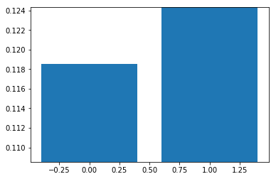

```python
total_cross=total_r[total_r.cost=='cross-entropy']
total_mse=total_r[total_r.cost=='mse']
total_sc=[np.mean(total_cross.score),np.mean(total_mse.score)]

plt.bar(range(len(total_sc)),total_sc)
plt.ylim([min(total_sc)-0.01,max(total_sc)])
```

Overall, MSE cost function performs better than cross-entropy in our model. The analysis of phi function and hidden layers are in 4.1.

We can see that the combination of mse, 1 hidden_layer, and linear phi has the best result, and the average f1_score in stratified 5-fold cross validation is 0.176734.

However, this score is **lower** than we expected, so we think multi-layer perceptron may be not very suitable for this dataset.

## 3.3 Visualize the magnitude of the gradients

Visualize the magnitude of the gradients in each layer of the neural network versus the training iteration. And we can clearly see that the gradients don't stay consistent in each layer and gradient decreases most in layer 3. This is expected because the layers closest to the output layer are most affected.

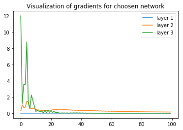

```python
clf_choose=CustizedPerceptron(**params,phi='linear', cost='mse',nl_hidden=2)
clf_choose.fit(X_train,y_train)
for i in range(clf_choose.n_layers):
    plt.plot(np.arange(len(clf_choose.grad_log[0])), clf_choose.grad_log[i], label='layer {}'.format(i+1))
plt.title('Visualization of gradients for choosen network')
plt.legend(loc='best')
plt.show()
```

# 4 Exceptional work

## 4.1 Comparison in four phi functions

We have implemented ReLU and SiLU phi functions in 3.1, and there are some analysis following 3.2.

```python
impute_grps = total_r.pivot_table(values=["score"], index=['cost','hidden_layer','phi'], aggfunc=np.mean)
print(impute_grps)
```

```
                                       score
cost          hidden_layer phi
cross-entropy 1            linear   0.170100
                           relu     0.159181
                           sigmoid  0.099599
                           silu     0.154720
              2            linear   0.165412
                           relu     0.131494
                           sigmoid  0.099599
                           silu     0.141441
              7            linear   0.002068
                           relu     0.099599
                           sigmoid  0.099599
                           silu     0.099599
mse           1            linear   0.176734
                           relu     0.176025
                           sigmoid  0.128697
                           silu     0.163152
              2            linear   0.147047
                           relu     0.157427
                           sigmoid  0.099599
                           silu     0.135303
              7            linear   0.002068
                           relu     0.106439
                           sigmoid  0.099599
                           silu     0.099599
```

```python
total_cross=total_r[total_r.cost=='cross-entropy']
```

```python
c_c1=total_cross[total_cross.phi=='sigmoid']
c_c2=total_cross[total_cross.phi=='linear']
c_c3=total_cross[total_cross.phi=='relu']
c_c4=total_cross[total_cross.phi=='silu']
```

[output not shown]

```
([], <a list of 0 Text xticklabel objects>)
```

[figure not shown]

```python
plt.xlabel('layer 1,2,7')
plt.ylabel('F1_score')
plt.title('cross_entrophy')

c_s=total_cross[total_cross.phi=='sigmoid']
x1=[10,20,30]
x2=[12,22,32]
x3=[14,24,34]
x4=[16,26,36]
y1=c_c1.score
y2=c_c2.score
y3=c_c3.score
y4=c_c4.score

plt.bar(x1, y1, facecolor='red', width=2, label = 'sigmoid')
plt.bar(x2, y2, facecolor='green', width=2, label = 'linear')
plt.bar(x3, y3, facecolor='blue', width=2, label = 'relu')
plt.bar(x4, y4, facecolor='orange', width=2, label = 'silu')
plt.legend(loc='best')
plt.xticks([])
```

```python
total_mse=total_r[total_r.cost=='mse']
c_c1=total_mse[total_mse.phi=='sigmoid']
c_c2=total_mse[total_mse.phi=='linear']
c_c3=total_mse[total_mse.phi=='relu']
c_c4=total_mse[total_mse.phi=='silu']
```

```
([], <a list of 0 Text xticklabel objects>)
```

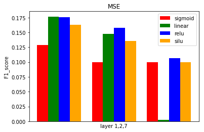

```python
plt.xlabel('layer 1,2,7')
plt.ylabel('F1_score')
plt.title('MSE')

c_s=total_cross[total_cross.phi=='sigmoid']
x1=[10,20,30]
x2=[12,22,32]
x3=[14,24,34]
x4=[16,26,36]
y1=c_c1.score
y2=c_c2.score
y3=c_c3.score
y4=c_c4.score

plt.bar(x1, y1, facecolor='red', width=2, label = 'sigmoid')
plt.bar(x2, y2, facecolor='green', width=2, label = 'linear')
plt.bar(x3, y3, facecolor='blue', width=2, label = 'relu')
plt.bar(x4, y4, facecolor='orange', width=2, label = 'silu')
plt.legend(loc='best')
plt.xticks([])
```

Basically, we can know that linear and Relu perform better than sigmoid and Silu, however, linear function performs badly in high hidden layers.

The performance deteriorates as the number of hidden layers increasing, and this situation is worth thinking about.

(These results are due to our dataset and it can be different in other situations.)

## 4.2 Comparison to Scikit-learn

```python
from sklearn.neural_network import MLPClassifier
# these values have been hand tuned
clf_s = MLPClassifier(hidden_layer_sizes=(30,30 ),
                    activation='logistic',
                    solver='sgd',
                    alpha=1e-4, # L2 penalty
                    batch_size='auto', # min of 200, num_samples
                    learning_rate='constant',
                    learning_rate_init=0.1, # only SGD
                    power_t=0.5,    # only SGD
                    max_iter=100,
                    shuffle=True,
                    random_state=1,
                    tol=1e-9, # for stopping
                    verbose=False,
                    warm_start=False,
                    momentum=0.9, # only SGD
                    nesterovs_momentum=True, # only SGD
                    early_stopping=False,
                    validation_fraction=0.1, # only if early_stop is true
                    beta_1=0.9, # adam decay rate of moment
                    beta_2=0.999, # adam decay rate of moment
                    epsilon=1e-08) # adam numerical stabilizer

%time clf.fit(X_train,y_train)
yhat = clf.predict(X_test)
print('f1_score:',f1_score(yhat,y_test,average='macro'))

%time clf_choose.fit(X_train,y_train)
yhat_choose=clf_choose.predict(X_test)
print('f1_score:',f1_score(yhat_choose,y_test,average='macro'))
```

```
Wall time: 993 ms
f1_score: 0.0994152046784
Wall time: 47.1 ms
f1_score: 0.190692328443
```